# İTÜ BÜYÜK VERİ ve İŞ ANALİTİĞİ EĞİTİM PROJESİ

**SERDAR ASMAOĞLU**

**HYUNDAİ İ20 MODEL ARAÇ DEĞERLEMESİ**

Bu çalışma İTÜ BÜYÜK VERİ ve İŞ ANALİTİĞİ eğitimi kapsamında gerçekleştirilmiştir. Amaç bu eğitim kapsamında işlenmiş konuların uygulamasına yönelik bir proje oluşturmaktır. Çalışmanın veri seti için Sahibinden.com sitesinden, 01.04.2019 tarihi itibari ile Hyundai i20 marka aracın verilmiş tüm ilan bilgileri Chrome Data Miner eklentisi kullanılarak çekilmiştir.

Bu veri seti aşağıda detayı gösterildiği şekilde düzenlenmiş, fiyat üzerinde etkili parametreler belirlenmiş ve tahmin için regresyon ve klasifikasyon modellemeleri yapılmıştır.

# Verinin Yüklenmesi

Veri bilgisayarda bulunanan excel dosyası üzerinden readxl kütüpanesi kullanılarak R’a yüklenmiştir.

```r
library(readxl)
Sahibinden_i20_data_rev3 <- read_excel("Sahibinden_i20_data_rev3.xlsx",
                                       col_types = c("text", "text", "text",
                                                     "text", "text", "numeric", "numeric",
                                                     "text", "numeric", "date", "skip",
                                                     "numeric", "skip","text"))

data<-data.frame(Sahibinden_i20_data_rev3)
head(data,3)
```

```
##    Yakit Sanziman     Kimden           Model                      Aciklama
## 1 benzin   manuel sahibinden    1.2 MPI Jump                 Çok temiz İ20
## 2 benzin   manuel sahibinden 1.2 D-CVVT Jump  36.000 de hatasız sahibinden
## 3 benzin   manuel sahibinden   1.2 MPI Style SAHİBİNDEN 2015 İ20 CAM TAVAN
##   Sene     Km       Renk Fiyat ilan.tarih ilan.kac.gunluk       il
## 1 2014 100000   Şampanya 47500 2019-04-01               0 İstanbul
## 2 2013  36000  Gümüş Gri 47500 2019-04-01               0 İstanbul
## 3 2015  88000 Kahverengi 58500 2019-04-01               0 Tekirdağ
```

```r
summary(data)
```

```
##     Yakit             Sanziman            Kimden
##  Length:3301        Length:3301        Length:3301
##  Class :character   Class :character   Class :character
##  Mode  :character   Mode  :character   Mode  :character
##
##
##
##     Model             Aciklama              Sene            Km
##  Length:3301        Length:3301        Min.   :2009   Min.   :     0
##  Class :character   Class :character   1st Qu.:2014   1st Qu.: 25671
##  Mode  :character   Mode  :character   Median :2015   Median : 53000
##                                        Mean   :2015   Mean   : 65978
##                                        3rd Qu.:2017   3rd Qu.: 93000
##                                        Max.   :2019   Max.   :595000
##      Renk               Fiyat          ilan.tarih
##  Length:3301        Min.   :  8600   Min.   :2018-04-13 00:00:00
##  Class :character   1st Qu.: 49100   1st Qu.:2019-03-12 00:00:00
##  Mode  :character   Median : 62500   Median :2019-03-20 00:00:00
##                     Mean   : 61290   Mean   :2019-03-17 08:44:47
##                     3rd Qu.: 72900   3rd Qu.:2019-03-26 00:00:00
##                     Max.   :112000   Max.   :2019-04-01 00:00:00
##  ilan.kac.gunluk       il
##  Min.   :  0.00   Length:3301
##  1st Qu.:  6.00   Class :character
##  Median : 12.00   Mode  :character
##  Mean   : 14.64
##  3rd Qu.: 20.00
##  Max.   :353.00
```

```r
data<-data.frame(data)
```

# Verinin Düzenlenmesi

Veri setinde yukarıda görüldüğü üzere “Model” sütununda Motor hacmi ve araç sınıfı bilgileri birlikte verilmiş. Bu nedenle motor hacmi ve model sınıfı bilgileri “Model” sütunundan çekilerek sırasıyla motor hacmi için “Motor” ve model sınıfı için “Alt.model” sütunları oluşturulmuştur.

```r
library(tidyr)
library(dplyr)
#Motor hacmini ayrı sütuna yazma


Motor<-separate(data,col=Model,c("Motor_hacim","2","3","4"),sep=" ") %>%
  data.frame()%>%
  replace_na(list(X4=""))
data$Motor=Motor[,4]


#Model sınıfını ayrı sütuna yazma
Model2<-unite(Motor,"X3","X4",col="Model2",sep=".") %>%
  data.frame()
data$Alt.model=Model2[,6]

head(data)
```

```
##    Yakit Sanziman     Kimden           Model
## 1 benzin   manuel sahibinden    1.2 MPI Jump
## 2 benzin   manuel sahibinden 1.2 D-CVVT Jump
## 3 benzin   manuel sahibinden   1.2 MPI Style
## 4 benzin   manuel sahibinden   1.2 MPI Style
## 5 benzin   manuel sahibinden   1.2 MPI Style
## 6 benzin   manuel sahibinden   1.2 MPI Style
##                                     Aciklama Sene     Km       Renk Fiyat
## 1                              Çok temiz İ20 2014 100000   Şampanya 47500
## 2               36.000 de hatasız sahibinden 2013  36000  Gümüş Gri 47500
## 3              SAHİBİNDEN 2015 İ20 CAM TAVAN 2015  88000 Kahverengi 58500
## 4               SIFIR AYARINDA TEMIZ ARABA!! 2015  38500      Beyaz 64000
## 5             İkinci Sahibinden tertemiz i20 2016  26400      Beyaz 64900
## 6 Sahibinden Temiz i20 1.2Mpi Style Panorama 2015 116000      Beyaz 56000
##   ilan.tarih ilan.kac.gunluk       il Motor Alt.model
## 1 2019-04-01               0 İstanbul   1.2     Jump.
## 2 2019-04-01               0 İstanbul   1.2     Jump.
## 3 2019-04-01               0 Tekirdağ   1.2    Style.
## 4 2019-04-01               0 Adıyaman   1.2    Style.
## 5 2019-04-01               0  Antalya   1.2    Style.
## 6 2019-04-01               0     Kars   1.2    Style.
```

# Betimleyici İstatistikler

```r
library(psych)
attach(data)
ortalama.fiyat <- data %>%
  select(Sanziman, Fiyat, Sene) %>%
  group_by(Sanziman, Sene) %>%
  summarise(Fiyatmean = mean(Fiyat), Fiyatstd=sd(Fiyat))
head(ortalama.fiyat)
```

```
## # A tibble: 6 x 4
## # Groups:   Sanziman [1]
##   Sanziman  Sene Fiyatmean Fiyatstd
##   <chr>    <dbl>     <dbl>    <dbl>
## 1 manuel    2009    36457.    4314.
## 2 manuel    2010    36759.    4477.
## 3 manuel    2011    37597.    4444.
## 4 manuel    2012    41382.    5627.
## 5 manuel    2013    44578.    5633.
## 6 manuel    2014    49989.    8200.
```

```r
describe(data$Fiyat)
```

```
##    vars    n     mean       sd median  trimmed     mad  min    max  range
## X1    1 3301 61290.37 14733.08  62500 61468.34 17049.9 8600 112000 103400
##     skew kurtosis     se
## X1 -0.11    -0.73 256.43
```

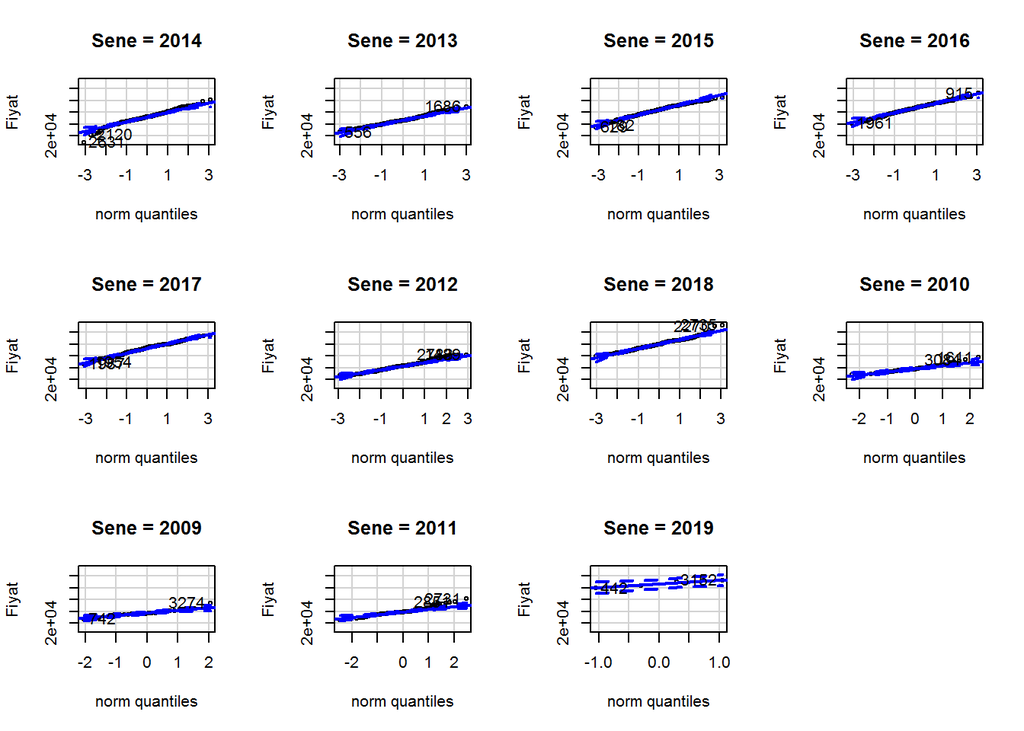

```r
library(car)

qqPlot(Fiyat~Sene,data=data)
```

# Korelasyon

Faktörler arasındaki korelasyon “PerformanceAnalytics” kütüphanesi kullanılarak aşağıdaki gibi incelenmiştir.

```r
#install.packages("PerformanceAnalytics")
library(PerformanceAnalytics)

## sadece numnerik kolonları seçiyor
data.nu<-select_if(data,is.numeric)
str(data.nu)
```

```
## 'data.frame':    3301 obs. of  4 variables:
##  $ Sene           : num  2014 2013 2015 2015 2016 ...
##  $ Km             : num  100000 36000 88000 38500 26400 116000 128000 98000 30000 31000 ...
##  $ Fiyat          : num  47500 47500 58500 64000 64900 ...
##  $ ilan.kac.gunluk: num  0 0 0 0 0 0 0 0 0 0 ...
```

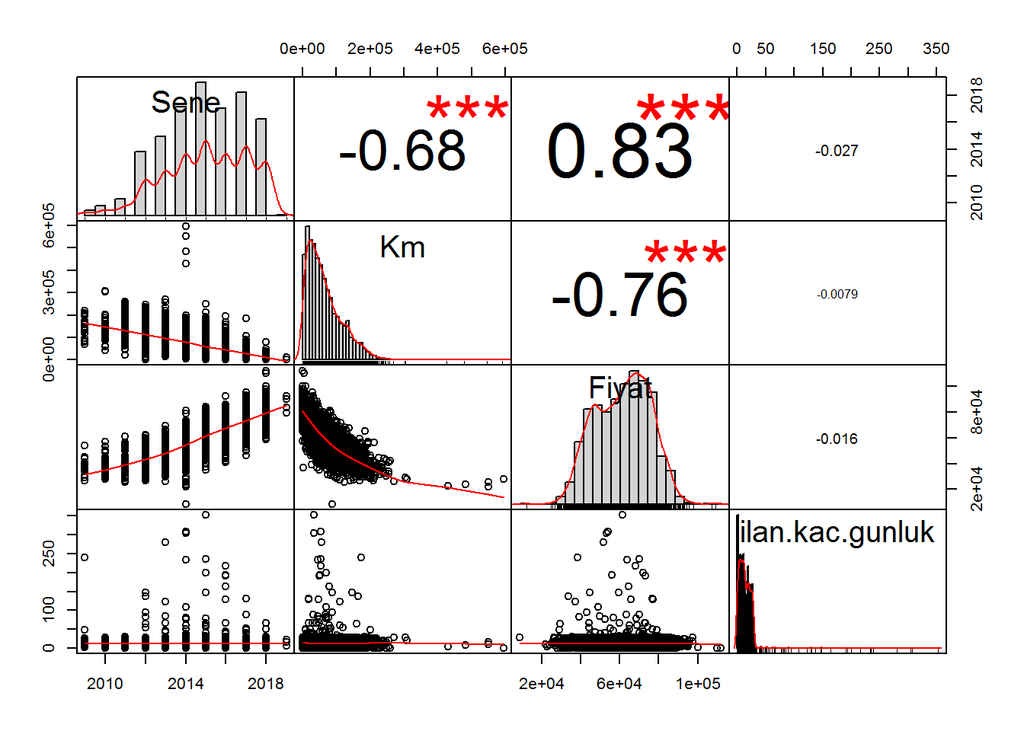

```r
chart.Correlation(data.nu)
```

Burada Bağımlı değişken “Fiyat”’tır. Yukarıda görüldüğü Fiyat ile aracın üretim yılı (“Sene”) ve “Km” si arasında güçlü bir koealasyon vardır. Burada dikkat edilecek bir konu da bağımsız değişkenlerden Sene ve Km arasında da bir korelasyon olduğudur.

# Çoklu Regresyon

## Numerik değerler ile;

Regresyonu gerçekleştirmek için ilk aşamada numerik parametreler seçilmiştir.

```r
library(MASS)
attach(data.nu)
data.nu.model<-lm(Fiyat~.,data=data.nu)
data.nu.model<-stepAIC(data.nu.model,direction = "backward")
```

```
## Start:  AIC=58635.81
## Fiyat ~ Sene + Km + ilan.kac.gunluk
##
##                   Df  Sum of Sq        RSS   AIC
## - ilan.kac.gunluk  1 1.0064e+07 1.7061e+11 58634
## <none>                          1.7060e+11 58636
## - Km               1 5.0609e+10 2.2121e+11 59491
## - Sene             1 1.2958e+11 3.0018e+11 60499
##
## Step:  AIC=58634
## Fiyat ~ Sene + Km
##
##        Df  Sum of Sq        RSS   AIC
## <none>               1.7061e+11 58634
## - Km    1 5.0623e+10 2.2124e+11 59490
## - Sene  1 1.2993e+11 3.0054e+11 60501
```

```r
summary(data.nu.model)
```

```
##
## Call:
## lm(formula = Fiyat ~ Sene + Km, data = data.nu)
##
## Residuals:
##    Min     1Q Median     3Q    Max
## -46120  -4644   -190   4906  31913
##
## Coefficients:
##               Estimate Std. Error t value Pr(>|t|)
## (Intercept) -8.289e+06  1.669e+05  -49.67   <2e-16 ***
## Sene         4.147e+03  8.275e+01   50.12   <2e-16 ***
## Km          -9.975e-02  3.189e-03  -31.28   <2e-16 ***
## ---
## Signif. codes:  0 '***' 0.001 '**' 0.01 '*' 0.05 '.' 0.1 ' ' 1
##
## Residual standard error: 7193 on 3298 degrees of freedom
## Multiple R-squared:  0.7618, Adjusted R-squared:  0.7617
## F-statistic:  5274 on 2 and 3298 DF,  p-value: < 2.2e-16
```

```r
library(broom)
glance(data.nu.model)
```

```
## # A tibble: 1 x 11
##   r.squared adj.r.squared sigma statistic p.value    df  logLik    AIC
## *     <dbl>         <dbl> <dbl>     <dbl>   <dbl> <int>   <dbl>  <dbl>
## 1     0.762         0.762 7193.     5274.       0     3 -33998. 68004.
## # ... with 3 more variables: BIC <dbl>, deviance <dbl>, df.residual <int>
```

Oluşturulan regreson modeli toplam değişkenliğin **% 76.2** ’sini açıklayabilmektedir. Sene, Km ve ilanın kaç günlük olduğu girdileri modelde kullanılmış, backward elimination analizi sonrasında ilanın kaç günlük olduğunun etkisinin anlamlı olmaığı anlaşılmıştır.

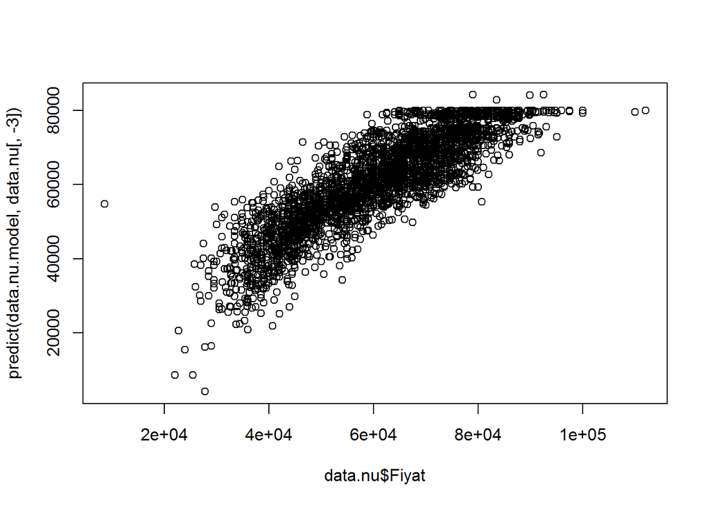

```r
plot(data.nu$Fiyat,predict(data.nu.model,data.nu[,-3]))
```

Gerçek ve tahmin değerlerin karşılaştırılması yukarıdaki gibidir

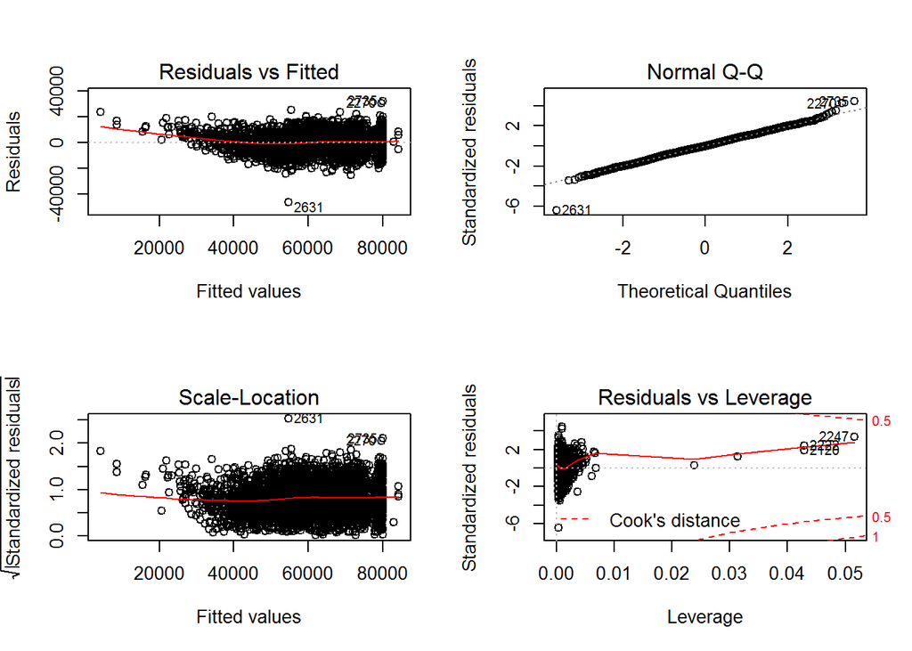

```r
par(mfrow=c(2,2))
plot(data.nu.model)
```

Artıkların analizi incelendiğinde;

Tahmin ve hataların “0” etrafında homojen dağılıp trend göstermemesi,

Hata terimlerinin normal dağılım gösteriyor olması,

Scale-location grafiğinde x ve y ekseniarasında belirgin bir ilişki olmaması,

Residuals vs Leverage grafiğinde görüldüğü üzere modeli etkileyecek bir outlier değerinin görünmemesi

regresyon analizi için yapılan kabullerin geçerli olduğunu göstermektedir

```r
#VIF
round(cov2cor(vcov(data.nu.model)),2)
```

```
##             (Intercept)  Sene    Km
## (Intercept)        1.00 -1.00 -0.68
## Sene              -1.00  1.00  0.68
## Km                -0.68  0.68  1.00
```

## Faktör ve numerik parametreler ile;

Kategorik verilerle ragresyon analizini gerçekleştirmek için “text” olan kolonlar faktöre çevrilmiş, kullanılmayacak olan parametreler veriden çıkarılmıştır.

```r
library(dplyr)
# text kolonları faktöre çeviriyor ve regresyonda kullanılmayacak parametreler veriden çıkarılıyor.
data<-mutate_if(data,is.character, as.factor)
data.fac<- select_if(data,is.factor)
data.fac<-data.fac[,-c(4,5,6,7)]
str(data.fac)
```

```
## 'data.frame':    3301 obs. of  5 variables:
##  $ Yakit    : Factor w/ 3 levels "benzin","dizel",..: 1 1 1 1 1 1 1 1 1 1 ...
##  $ Sanziman : Factor w/ 2 levels "manuel","otomatik": 1 1 1 1 1 1 1 1 1 1 ...
##  $ Kimden   : Factor w/ 2 levels "galeri","sahibinden": 2 2 2 2 2 2 2 2 2 2 ...
##  $ Motor    : Factor w/ 3 levels "1.0","1.2","1.4": 2 2 2 2 2 2 2 2 2 2 ...
##  $ Alt.model: Factor w/ 12 levels "Active.Elite",..: 6 6 10 10 10 10 6 10 10 10 ...
```

```r
library(dplyr)
# Numerik ve faktör paramatreler bir araya getiriliyor.
data.rev2<-cbind(data.fac,data.nu)
str(data.rev2)
```

```
## 'data.frame':    3301 obs. of  9 variables:
##  $ Yakit          : Factor w/ 3 levels "benzin","dizel",..: 1 1 1 1 1 1 1 1 1 1 ...
##  $ Sanziman       : Factor w/ 2 levels "manuel","otomatik": 1 1 1 1 1 1 1 1 1 1 ...
##  $ Kimden         : Factor w/ 2 levels "galeri","sahibinden": 2 2 2 2 2 2 2 2 2 2 ...
##  $ Motor          : Factor w/ 3 levels "1.0","1.2","1.4": 2 2 2 2 2 2 2 2 2 2 ...
##  $ Alt.model      : Factor w/ 12 levels "Active.Elite",..: 6 6 10 10 10 10 6 10 10 10 ...
##  $ Sene           : num  2014 2013 2015 2015 2016 ...
##  $ Km             : num  100000 36000 88000 38500 26400 116000 128000 98000 30000 31000 ...
##  $ Fiyat          : num  47500 47500 58500 64000 64900 ...
##  $ ilan.kac.gunluk: num  0 0 0 0 0 0 0 0 0 0 ...
```

Regresyon analizi için kullanılacak değişkenler özetle aşağıdaki gibidir;

```r
parametreler<-c(names(data.rev2))
parametreler<-as.vector(parametreler)
print(parametreler)
```

```
## [1] "Yakit"           "Sanziman"        "Kimden"          "Motor"
## [5] "Alt.model"       "Sene"            "Km"              "Fiyat"
## [9] "ilan.kac.gunluk"
```

```r
library(MASS)
attach(data.rev2)
# Doğrusal regresyon modeli, numerik ve faktör değerler ile

data.rev2.model <- lm(Fiyat~.,data=data.rev2)
data.rev3.model<-stepAIC(data.rev2.model,direction = "backward")
```

```
## Start:  AIC=56104.73
## Fiyat ~ Yakit + Sanziman + Kimden + Motor + Alt.model + Sene +
##     Km + ilan.kac.gunluk
##
##                   Df  Sum of Sq        RSS   AIC
## - ilan.kac.gunluk  1 2.0711e+07 7.8456e+10 56104
## <none>                          7.8435e+10 56105
## - Kimden           1 6.0251e+08 7.9038e+10 56128
## - Motor            2 1.0534e+09 7.9489e+10 56145
## - Yakit            2 1.6721e+09 8.0107e+10 56170
## - Sanziman         1 1.6798e+09 8.0115e+10 56173
## - Km               1 2.8745e+10 1.0718e+11 57133
## - Alt.model       11 4.2333e+10 1.2077e+11 57507
## - Sene             1 5.3931e+10 1.3237e+11 57830
##
## Step:  AIC=56103.6
## Fiyat ~ Yakit + Sanziman + Kimden + Motor + Alt.model + Sene +
##     Km
##
##             Df  Sum of Sq        RSS   AIC
## <none>                    7.8456e+10 56104
## - Kimden     1 5.9109e+08 7.9047e+10 56126
## - Motor      2 1.0554e+09 7.9511e+10 56144
## - Yakit      2 1.6714e+09 8.0127e+10 56169
## - Sanziman   1 1.6762e+09 8.0132e+10 56171
## - Km         1 2.8724e+10 1.0718e+11 57131
## - Alt.model 11 4.2322e+10 1.2078e+11 57506
## - Sene       1 5.3992e+10 1.3245e+11 57830
```

```r
summary(data.rev3.model)
```

```
##
## Call:
## lm(formula = Fiyat ~ Yakit + Sanziman + Kimden + Motor + Alt.model +
##     Sene + Km, data = data.rev2)
##
## Residuals:
##    Min     1Q Median     3Q    Max
## -43805  -2504     33   2759  26720
##
## Coefficients:
##                        Estimate Std. Error t value Pr(>|t|)
## (Intercept)          -6.709e+06  1.434e+05 -46.795  < 2e-16 ***
## Yakitdizel            7.286e+03  1.097e+03   6.639 3.68e-11 ***
## Yakitlpg              1.571e+03  2.691e+02   5.838 5.80e-09 ***
## Sanzimanotomatik      9.158e+03  1.094e+03   8.372  < 2e-16 ***
## Kimdensahibinden      9.289e+02  1.868e+02   4.972 6.97e-07 ***
## Motor1.2             -1.421e+04  2.396e+03  -5.930 3.35e-09 ***
## Motor1.4             -1.484e+04  2.233e+03  -6.643 3.57e-11 ***
## Alt.modelCoupe.      -6.935e+03  5.321e+03  -1.303  0.19260
## Alt.modelElite.      -3.432e+03  4.905e+03  -0.700  0.48416
## Alt.modelElite.Smart -1.505e+03  4.917e+03  -0.306  0.75963
## Alt.modelGo.         -1.331e+04  5.663e+03  -2.350  0.01885 *
## Alt.modelJump.       -1.384e+04  4.905e+03  -2.822  0.00480 **
## Alt.modelSelect.     -6.504e+03  5.161e+03  -1.260  0.20767
## Alt.modelSense.      -1.070e+04  4.917e+03  -2.177  0.02955 *
## Alt.modelStar.       -7.141e+03  5.247e+03  -1.361  0.17365
## Alt.modelStyle.      -7.110e+03  4.901e+03  -1.451  0.14696
## Alt.modelTeam.       -8.935e+03  4.940e+03  -1.809  0.07057 .
## Alt.modelTune.       -1.592e+04  5.250e+03  -3.033  0.00244 **
## Sene                  3.371e+03  7.095e+01  47.518  < 2e-16 ***
## Km                   -8.408e-02  2.426e-03 -34.659  < 2e-16 ***
## ---
## Signif. codes:  0 '***' 0.001 '**' 0.01 '*' 0.05 '.' 0.1 ' ' 1
##
## Residual standard error: 4890 on 3281 degrees of freedom
## Multiple R-squared:  0.8905, Adjusted R-squared:  0.8898
## F-statistic:  1404 on 19 and 3281 DF,  p-value: < 2.2e-16
```

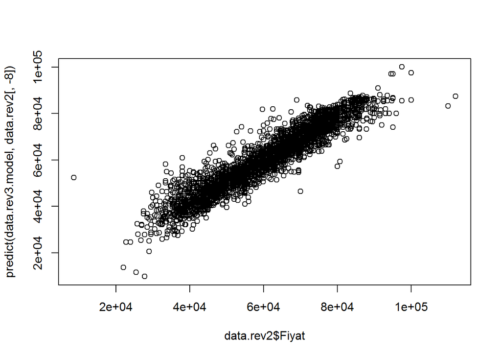

```r
plot(data.rev2$Fiyat,predict(data.rev3.model,data.rev2[,-8]))
```

Gerçek ve tahmin değerlerin karşılaştırılması yukarıdaki gibidir

```r
library(broom)
glance(data.rev3.model)
```

```
## # A tibble: 1 x 11
##   r.squared adj.r.squared sigma statistic p.value    df  logLik    AIC
## *     <dbl>         <dbl> <dbl>     <dbl>   <dbl> <int>   <dbl>  <dbl>
## 1     0.890         0.890 4890.     1404.       0    20 -32716. 65473.
## # ... with 3 more variables: BIC <dbl>, deviance <dbl>, df.residual <int>
```

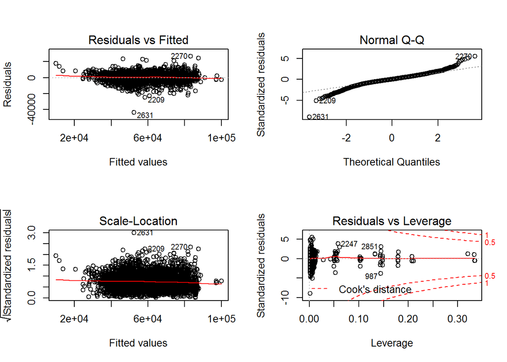

```r
par(mfrow=c(2,2))
plot(data.rev3.model)
```

Oluşturulan regreson modeli toplam değişkenliğin **% 89** ’unu açıklayabilmektedir.

## ANOVA Analizi (Two-Way)

```r
# Two way Anova
library(stats)

data.anova<-aov(Fiyat~Yakit+Sanziman+Motor,data=data.fac)
step.anova<-stepAIC(data.anova,direction="backward")
```

```
## Start:  AIC=62095.27
## Fiyat ~ Yakit + Sanziman + Motor
##
##            Df  Sum of Sq        RSS   AIC
## <none>                   4.8596e+11 62095
## - Motor     2 5.3311e+09 4.9129e+11 62127
## - Yakit     2 1.2291e+10 4.9825e+11 62174
## - Sanziman  1 1.6309e+10 5.0227e+11 62202
```

```r
summary(step.anova)
```

```
##               Df    Sum Sq   Mean Sq F value   Pr(>F)
## Yakit          2 5.774e+10 2.887e+10  195.75  < 2e-16 ***
## Sanziman       1 1.673e+11 1.673e+11 1134.20  < 2e-16 ***
## Motor          2 5.331e+09 2.666e+09   18.07 1.56e-08 ***
## Residuals   3295 4.860e+11 1.475e+08
## ---
## Signif. codes:  0 '***' 0.001 '**' 0.01 '*' 0.05 '.' 0.1 ' ' 1
```

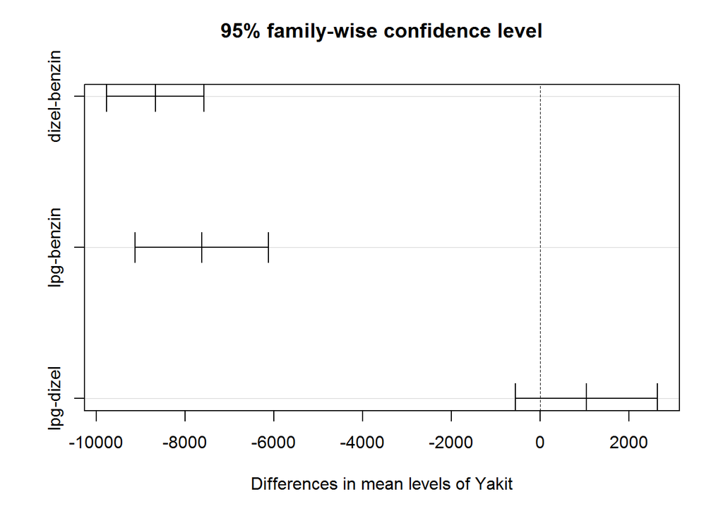

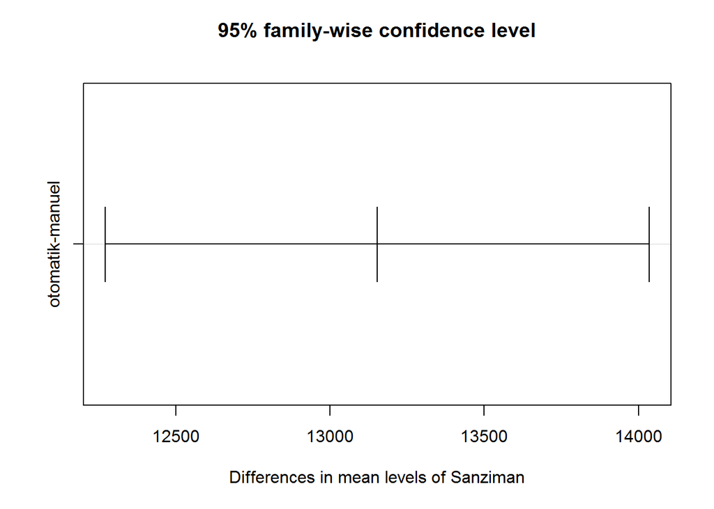

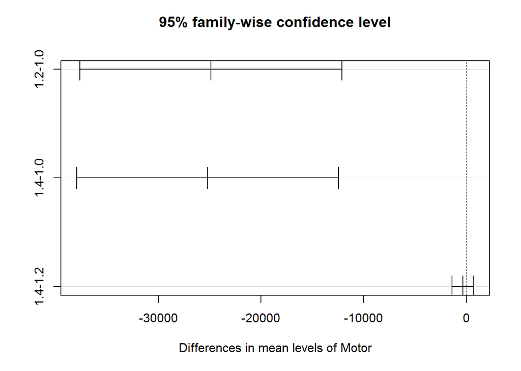

```r
plot(TukeyHSD(data.anova))
```

Aracın dizel-benzin, lpg-benzin, otomatik-manuel ve motor hacimin 12.-1.0, 1.4-1.0 olması arasında anlamlı bir ortalama fiyat farkı vardır. lgg-dizel ve 1.2-1.4 karşışalrırması arasında fiyat farkı vardır denemez.

Aşağıdaki özelliklerdeki Hyundai i20 model araç için piyasa fiyatı değerlemesi yapılacaktır.

```r
i20<-data.frame(Alt.model=c("Elite.Smart"),Yakit=c("benzin"),Sanziman=c("otomatik"),Kimden=c("sahibinden"),Sene=as.numeric(c("2015")),Km=as.numeric(c("40000")),Fiyat=as.factor(c("100000")),ilan.kac.gunluk=as.numeric(c("0")),Motor=c("1.4"))
Tahmin1<-predict(data.nu.model,i20)
```

Sadece numerik değerler kullanılan modelin performansı;

```r
glance(data.nu.model)
```

```
## # A tibble: 1 x 11
##   r.squared adj.r.squared sigma statistic p.value    df  logLik    AIC
## *     <dbl>         <dbl> <dbl>     <dbl>   <dbl> <int>   <dbl>  <dbl>
## 1     0.762         0.762 7193.     5274.       0     3 -33998. 68004.
## # ... with 3 more variables: BIC <dbl>, deviance <dbl>, df.residual <int>
```

```r
RMSE1<-sqrt(mean((data.nu$Fiyat-predict(data.nu.model,data.nu[,-3]))^2))
```

[output not shown]

Numerik ve Kategorik değerlerin birlikte kullanıldığı modelin performansı;

```r
glance(data.rev2.model)
```

```
## # A tibble: 1 x 11
##   r.squared adj.r.squared sigma statistic p.value    df  logLik    AIC
## *     <dbl>         <dbl> <dbl>     <dbl>   <dbl> <int>   <dbl>  <dbl>
## 1     0.891         0.890 4890.     1334.       0    21 -32715. 65475.
## # ... with 3 more variables: BIC <dbl>, deviance <dbl>, df.residual <int>
```

```r
  print(paste("Numerik ve Kategorik değerler ile yapılan regresyon modeli için fiyat tahmini sonucu:",Tahmin2, "TL ve RMSE hata değeri:",RMSE2,"dir."))
```

```
## [1] "Numerik ve Kategorik değerler ile yapılan regresyon modeli için fiyat tahmini sonucu: 75016.512359187 TL ve RMSE hata değeri: 4875.1753510251 dir."
```

# Grafiksel Gösterimler

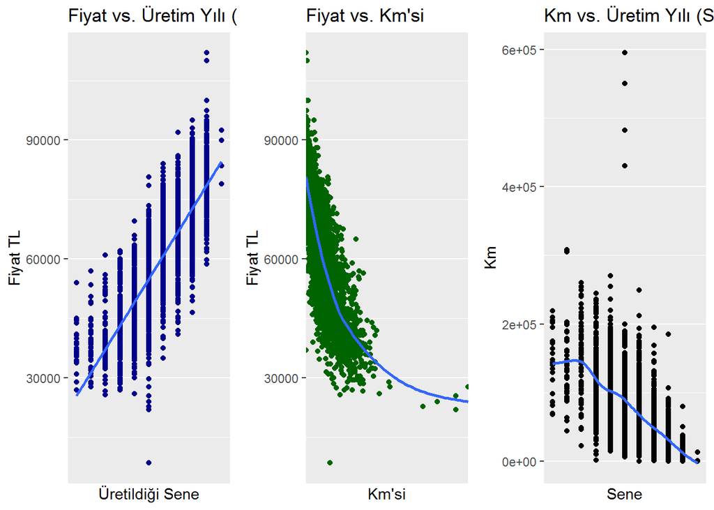

```r
#install.packages("ggplot2")
library(ggplot2)
#install.packages("gridExtra")
library(gridExtra)


g1<-ggplot(data=data.rev2)+
  geom_point(mapping=aes(x=Sene, y=Fiyat),col="darkblue")+
  geom_smooth(aes(x=Sene,y=Fiyat),method="lm", se=F)+
  ggtitle("Fiyat vs. Üretim Yılı (Sene)")+
  scale_y_continuous(name = "Fiyat TL")+
  scale_x_discrete(name = "Üretildiği Sene")


g2<-ggplot(data=data.rev2)+
  geom_point(mapping=aes(x=Km, y=Fiyat),col="darkgreen")+
  geom_smooth(aes(x=Km,y=Fiyat),method="auto", se=F)+
  ggtitle("Fiyat vs. Km'si")+
  scale_y_continuous(name = "Fiyat TL")+
  scale_x_discrete(name = "Km'si")


g3<-ggplot(data=data.rev2)+
  geom_point(mapping=aes(x=Sene, y=Km))+
  geom_smooth(aes(x=Sene,y=Km),method="auto", se=F)+
  ggtitle("Km vs. Üretim Yılı (Sene)")+
  scale_y_continuous(name = "Km")+
  scale_x_discrete(name = "Sene")


grid.arrange(g1,g2,g3,nrow=1,ncol=3)
```

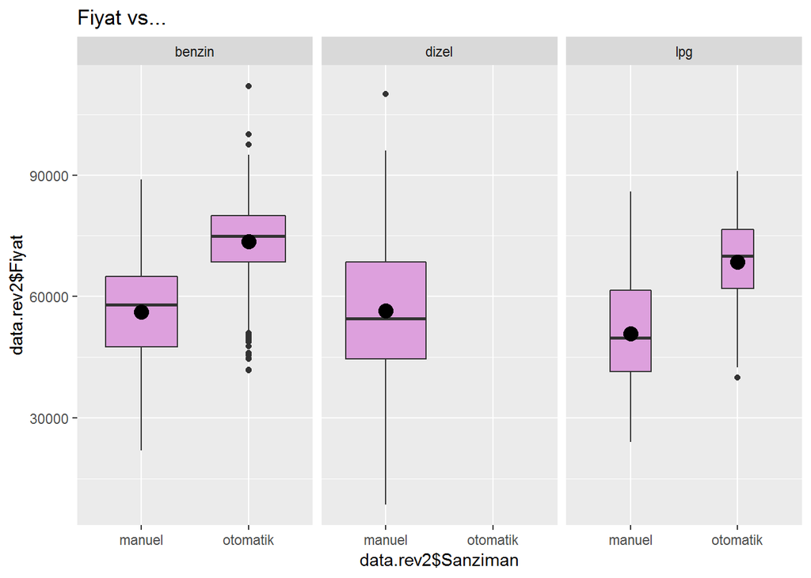

```r
ggplot(data.rev2,aes(x=data.rev2$Sanziman, y=data.rev2$Fiyat))+
  geom_boxplot(varwidth=T, fill="plum")+
  ggtitle("Fiyat vs...")+
  stat_summary(fun.y=mean,geom="point",shape=16,size=4)+
  facet_wrap(~Yakit)
```

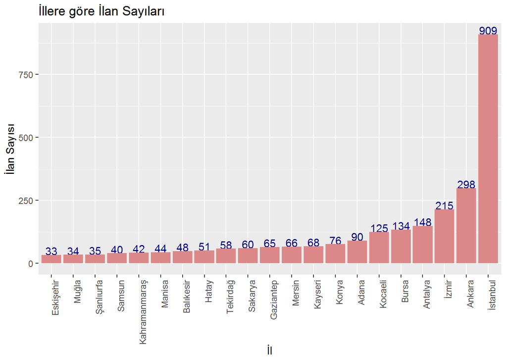

```r
library(dplyr)
data.map<-data %>%
  group_by(il)%>%
  summarise(n=n(),avg=mean(Fiyat,na.rm=TRUE)) %>%
  arrange(n) %>%
  as.data.frame()%>%
  filter(n>30)


ggplot(data=data.map,aes(x=il,y=n))+
  geom_text(aes(reorder(il,n),label=n),vjust=0.01,color="darkblue")+
  geom_bar(mapping=aes(il,n),fill="#DD8888",stat="identity")+
  theme(axis.text.x = element_text(angle = 90, vjust = 1, hjust = 1))+
  ggtitle("İllere göre İlan Sayıları")+
  scale_y_continuous(name = "İlan Sayısı")+
  scale_x_discrete(name = "İl")
```

# Neural Networks ile Tahminleme

Bu kısımda yapay sinir ağları algoritması kullanılarak aracın fiyatının tahmininin yapılması amaçlanmıştır.

```r
#install.packages("MASS")
#library(MASS)
#install.packages("neuralnet")
#require(neuralnet)
library(neuralnet)
library(dplyr)
```

## Test ve Train verilerinin oluşturulması (Partitioning)

```r
set.seed(1234)
degerler <- sample(2, nrow(data.rev2), replace = TRUE, prob = c(0.7, 0.3))
train.data <- as.data.frame(data.rev2[degerler == 1, ])
test.data <- as.data.frame(data.rev2[degerler == 2, ])

# Numerik parametreler için test ve train verileri

train.data.nu<-select_if(train.data,is.numeric)
str(train.data.nu)
```

```
## 'data.frame':    2337 obs. of  4 variables:
##  $ Sene           : num  2014 2013 2015 2015 2015 ...
##  $ Km             : num  100000 36000 88000 38500 116000 128000 98000 30000 31000 35000 ...
##  $ Fiyat          : num  47500 47500 58500 64000 56000 ...
##  $ ilan.kac.gunluk: num  0 0 0 0 0 0 0 0 0 0 ...
```

```r
test.data.nu<-select_if(test.data,is.numeric)
str(test.data.nu)
```

```
## 'data.frame':    964 obs. of  4 variables:
##  $ Sene           : num  2016 2013 2015 2014 2015 ...
##  $ Km             : num  26400 103500 51000 76000 34000 ...
##  $ Fiyat          : num  64900 44000 58000 53500 62000 ...
##  $ ilan.kac.gunluk: num  0 1 1 2 0 1 0 2 2 3 ...
```

```r
normalize <- function(x){
  return((x-min(x))/(max(x)-min(x)))
}
train.data.nu.nor <- apply(train.data.nu,2,normalize)
str(train.data.nu.nor)
```

```
##  num [1:2337, 1:4] 0.5 0.4 0.6 0.6 0.6 0.4 0.6 0.6 0.6 0.7 ...
##  - attr(*, "dimnames")=List of 2
##   ..$ : chr [1:2337] "1" "2" "3" "4" ...
##   ..$ : chr [1:4] "Sene" "Km" "Fiyat" "ilan.kac.gunluk"
```

```r
test.data.nu.nor <- apply(test.data.nu,2,normalize)
str(test.data.nu.nor)
```

```
##  num [1:964, 1:4] 0.7 0.4 0.6 0.5 0.6 0.6 0.8 0.9 0.6 0.4 ...
##  - attr(*, "dimnames")=List of 2
##   ..$ : chr [1:964] "5" "14" "16" "26" ...
##   ..$ : chr [1:4] "Sene" "Km" "Fiyat" "ilan.kac.gunluk"
```

Kategorik değişkenler model.matrix() fonksiyonu kullanılarak “1” ve “0” dan oluşan numerik değişkenlere dönüştürülmüştür.

```r
# Faktör parametreler için test train verisi

train.data.fac<-select_if(train.data,is.factor)

Alt.model.train.mat<-as.data.frame(model.matrix(~train.data.fac$Alt.model-1))
Sanziman.train.mat<-as.data.frame(model.matrix(~train.data.fac$Sanziman-1))
Yakit.train.mat<-as.data.frame(model.matrix(~train.data.fac$Yakit-1))
Kimden.train.mat<-as.data.frame(model.matrix(~train.data.fac$Kimden-1))

train.data.mat<-as.data.frame(cbind(Alt.model.train.mat,Sanziman.train.mat,Yakit.train.mat,Kimden.train.mat))
str(train.data.mat)
```

```
## 'data.frame':    2337 obs. of  19 variables:
##  $ train.data.fac$Alt.modelActive.Elite: num  0 0 0 0 0 0 0 0 0 0 ...
##  $ train.data.fac$Alt.modelCoupe.      : num  0 0 0 0 0 0 0 0 0 0 ...
##  $ train.data.fac$Alt.modelElite.      : num  0 0 0 0 0 0 0 0 0 0 ...
##  $ train.data.fac$Alt.modelElite.Smart : num  0 0 0 0 0 0 0 0 0 0 ...
##  $ train.data.fac$Alt.modelGo.         : num  0 0 0 0 0 0 0 0 0 0 ...
##  $ train.data.fac$Alt.modelJump.       : num  1 1 0 0 0 1 0 0 0 1 ...
##  $ train.data.fac$Alt.modelSelect.     : num  0 0 0 0 0 0 0 0 0 0 ...
##  $ train.data.fac$Alt.modelSense.      : num  0 0 0 0 0 0 0 0 0 0 ...
##  $ train.data.fac$Alt.modelStar.       : num  0 0 0 0 0 0 0 0 0 0 ...
##  $ train.data.fac$Alt.modelStyle.      : num  0 0 1 1 1 0 1 1 1 0 ...
##  $ train.data.fac$Alt.modelTeam.       : num  0 0 0 0 0 0 0 0 0 0 ...
##  $ train.data.fac$Alt.modelTune.       : num  0 0 0 0 0 0 0 0 0 0 ...
##  $ train.data.fac$Sanzimanmanuel       : num  1 1 1 1 1 1 1 1 1 1 ...
##  $ train.data.fac$Sanzimanotomatik     : num  0 0 0 0 0 0 0 0 0 0 ...
##  $ train.data.fac$Yakitbenzin          : num  1 1 1 1 1 1 1 1 1 1 ...
##  $ train.data.fac$Yakitdizel           : num  0 0 0 0 0 0 0 0 0 0 ...
##  $ train.data.fac$Yakitlpg             : num  0 0 0 0 0 0 0 0 0 0 ...
##  $ train.data.fac$Kimdengaleri         : num  0 0 0 0 0 0 0 0 0 0 ...
##  $ train.data.fac$Kimdensahibinden     : num  1 1 1 1 1 1 1 1 1 1 ...
```

```r
test.data.fac<-select_if(test.data,is.factor)

Alt.model.test.mat<-as.data.frame(model.matrix(~test.data.fac$Alt.model-1))
Sanziman.test.mat<-as.data.frame(model.matrix(~test.data.fac$Sanziman-1))
Yakit.test.mat<-as.data.frame(model.matrix(~test.data.fac$Yakit-1))
Kimden.test.mat<-as.data.frame(model.matrix(~test.data.fac$Kimden-1))
test.data.mat<-as.data.frame(cbind(Alt.model.test.mat,Sanziman.test.mat,Yakit.test.mat,Kimden.test.mat))
str(test.data.mat)
```

```
## 'data.frame':    964 obs. of  19 variables:
##  $ test.data.fac$Alt.modelActive.Elite: num  0 0 0 0 0 0 0 0 0 0 ...
##  $ test.data.fac$Alt.modelCoupe.      : num  0 0 0 0 0 0 0 0 0 0 ...
##  $ test.data.fac$Alt.modelElite.      : num  0 0 0 0 0 0 0 0 0 1 ...
##  $ test.data.fac$Alt.modelElite.Smart : num  0 0 0 0 0 0 0 0 0 0 ...
##  $ test.data.fac$Alt.modelGo.         : num  0 0 0 0 0 0 0 0 0 0 ...
##  $ test.data.fac$Alt.modelJump.       : num  0 1 0 0 0 1 1 0 0 0 ...
##  $ test.data.fac$Alt.modelSelect.     : num  0 0 0 0 0 0 0 0 0 0 ...
##  $ test.data.fac$Alt.modelSense.      : num  0 0 0 1 0 0 0 0 0 0 ...
##  $ test.data.fac$Alt.modelStar.       : num  0 0 0 0 0 0 0 0 0 0 ...
##  $ test.data.fac$Alt.modelStyle.      : num  1 0 1 0 1 0 0 1 1 0 ...
##  $ test.data.fac$Alt.modelTeam.       : num  0 0 0 0 0 0 0 0 0 0 ...
##  $ test.data.fac$Alt.modelTune.       : num  0 0 0 0 0 0 0 0 0 0 ...
##  $ test.data.fac$Sanzimanmanuel       : num  1 1 1 1 1 1 1 1 1 1 ...
##  $ test.data.fac$Sanzimanotomatik     : num  0 0 0 0 0 0 0 0 0 0 ...
##  $ test.data.fac$Yakitbenzin          : num  1 1 1 1 1 1 1 1 1 1 ...
##  $ test.data.fac$Yakitdizel           : num  0 0 0 0 0 0 0 0 0 0 ...
##  $ test.data.fac$Yakitlpg             : num  0 0 0 0 0 0 0 0 0 0 ...
##  $ test.data.fac$Kimdengaleri         : num  0 0 0 0 0 0 0 0 0 0 ...
##  $ test.data.fac$Kimdensahibinden     : num  1 1 1 1 1 1 1 1 1 1 ...
```

```r
train.data.rev<-as.data.frame(cbind(train.data.nu.nor,train.data.mat))
str(train.data)
```

```
## 'data.frame':    2337 obs. of  9 variables:
##  $ Yakit          : Factor w/ 3 levels "benzin","dizel",..: 1 1 1 1 1 1 1 1 1 1 ...
##  $ Sanziman       : Factor w/ 2 levels "manuel","otomatik": 1 1 1 1 1 1 1 1 1 1 ...
##  $ Kimden         : Factor w/ 2 levels "galeri","sahibinden": 2 2 2 2 2 2 2 2 2 2 ...
##  $ Motor          : Factor w/ 3 levels "1.0","1.2","1.4": 2 2 2 2 2 2 2 2 2 2 ...
##  $ Alt.model      : Factor w/ 12 levels "Active.Elite",..: 6 6 10 10 10 6 10 10 10 6 ...
##  $ Sene           : num  2014 2013 2015 2015 2015 ...
##  $ Km             : num  100000 36000 88000 38500 116000 128000 98000 30000 31000 35000 ...
##  $ Fiyat          : num  47500 47500 58500 64000 56000 ...
##  $ ilan.kac.gunluk: num  0 0 0 0 0 0 0 0 0 0 ...
```

```r
test.data.rev<-as.data.frame(cbind(test.data.nu.nor,test.data.mat))
str(test.data.rev)
```

```
## 'data.frame':    964 obs. of  23 variables:
##  $ Sene                               : num  0.7 0.4 0.6 0.5 0.6 0.6 0.8 0.9 0.6 0.4 ...
##  $ Km                                 : num  0.048 0.1882 0.0927 0.1382 0.0618 ...
##  $ Fiyat                              : num  0.547 0.257 0.451 0.389 0.507 ...
##  $ ilan.kac.gunluk                    : num  0 0.00283 0.00283 0.00567 0 ...
##  $ test.data.fac$Alt.modelActive.Elite: num  0 0 0 0 0 0 0 0 0 0 ...
##  $ test.data.fac$Alt.modelCoupe.      : num  0 0 0 0 0 0 0 0 0 0 ...
##  $ test.data.fac$Alt.modelElite.      : num  0 0 0 0 0 0 0 0 0 1 ...
##  $ test.data.fac$Alt.modelElite.Smart : num  0 0 0 0 0 0 0 0 0 0 ...
##  $ test.data.fac$Alt.modelGo.         : num  0 0 0 0 0 0 0 0 0 0 ...
##  $ test.data.fac$Alt.modelJump.       : num  0 1 0 0 0 1 1 0 0 0 ...
##  $ test.data.fac$Alt.modelSelect.     : num  0 0 0 0 0 0 0 0 0 0 ...
##  $ test.data.fac$Alt.modelSense.      : num  0 0 0 1 0 0 0 0 0 0 ...
##  $ test.data.fac$Alt.modelStar.       : num  0 0 0 0 0 0 0 0 0 0 ...
##  $ test.data.fac$Alt.modelStyle.      : num  1 0 1 0 1 0 0 1 1 0 ...
##  $ test.data.fac$Alt.modelTeam.       : num  0 0 0 0 0 0 0 0 0 0 ...
##  $ test.data.fac$Alt.modelTune.       : num  0 0 0 0 0 0 0 0 0 0 ...
##  $ test.data.fac$Sanzimanmanuel       : num  1 1 1 1 1 1 1 1 1 1 ...
##  $ test.data.fac$Sanzimanotomatik     : num  0 0 0 0 0 0 0 0 0 0 ...
##  $ test.data.fac$Yakitbenzin          : num  1 1 1 1 1 1 1 1 1 1 ...
##  $ test.data.fac$Yakitdizel           : num  0 0 0 0 0 0 0 0 0 0 ...
##  $ test.data.fac$Yakitlpg             : num  0 0 0 0 0 0 0 0 0 0 ...
##  $ test.data.fac$Kimdengaleri         : num  0 0 0 0 0 0 0 0 0 0 ...
##  $ test.data.fac$Kimdensahibinden     : num  1 1 1 1 1 1 1 1 1 1 ...
```

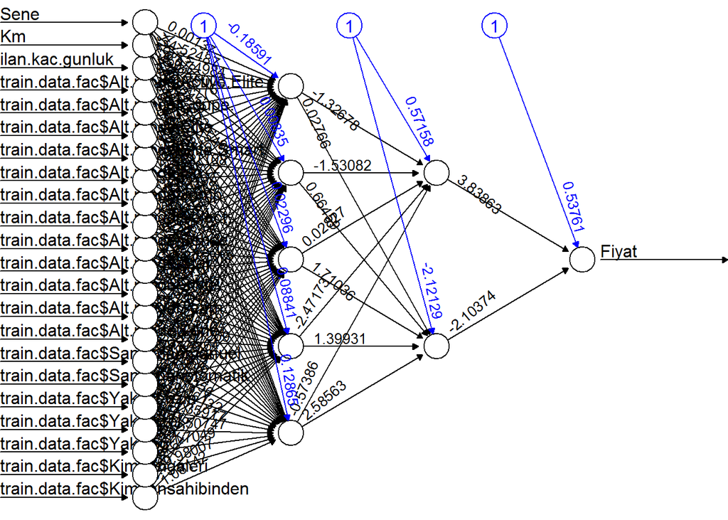

```r
n = names(train.data.rev)
f = as.formula(paste("Fiyat ~ ", paste(n[!n %in% "Fiyat"],collapse = " + ")))
neural.net.model = neuralnet(f, data = train.data.rev, hidden = c(5,2), err.fct ="sse",algorithm = "rprop+", linear.output= FALSE)

plot(neural.net.model,rep="best")
```

## Modelin performansının değerlendirilmesi;

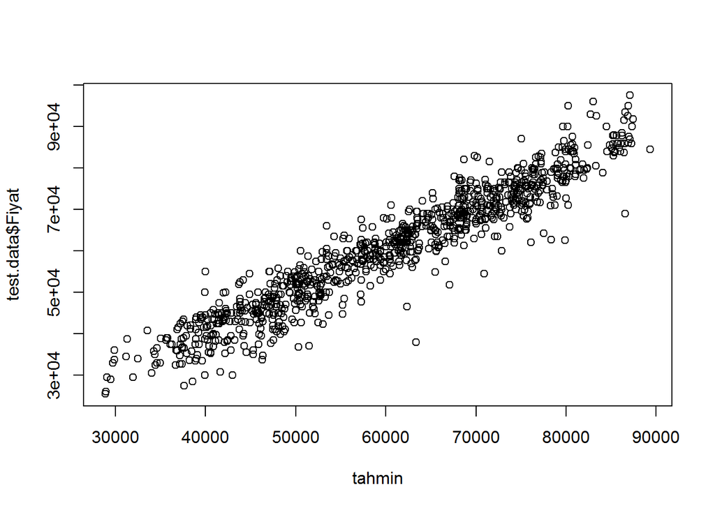

```r
tahmin.mat = neuralnet::compute(neural.net.model,test.data.rev[,c(1:2,4:23)])

tahmin<-tahmin.mat$net.result*(max(train.data.nu$Fiyat)-min(train.data.nu$Fiyat))+min(train.data.nu$Fiyat)
Gercek<-test.data$Fiyat
plot(tahmin,test.data$Fiyat)
```

```r
cor(tahmin.mat$net.result,test.data$Fiyat)
```

```
##           [,1]
## [1,] 0.9512246
```

```r
RMSE3 <- (sum((tahmin - test.data$Fiyat)^2)/nrow(test.data))^0.5
```

[output not shown]

# Naive Bayes Yöntemi ile Sınıflandırma

Bu kısımda aracın özellikleri dikkate alınarak aracın satışının 1 ay gibi bir süreden daha uzun sürüp sürmeyeceği sınıflandırma metodu ile modellenmeye çalışılmıştır. Verisetinden öncelikle ilan süresi 1 aydan az olanlar çıkarılmış, geri kalan veriler ilan süreleri 54 gün üzeri olanlar 1 aydan önce satılamaz ve satılabilir olarak binary forma getirilmiştir.

```r
library(dplyr)

data.rev3<- data.rev2 %>%
  filter(ilan.kac.gunluk>28)

data.rev3$Sene<-as.integer(data.rev3$Sene)


data.rev3$Satis<-ifelse(data.rev3$ilan.kac.gunluk>54,"4haftadanöncesatılmaz","4haftadanoncesatılabilir")
data.rev3$Satis<-as.factor(data.rev3$Satis)
data.rev3.bin<-data.rev3[,-9]
str(data.rev3.bin)
```

```
## 'data.frame':    131 obs. of  9 variables:
##  $ Yakit    : Factor w/ 3 levels "benzin","dizel",..: 1 1 1 1 1 1 1 1 1 1 ...
##  $ Sanziman : Factor w/ 2 levels "manuel","otomatik": 1 1 1 1 1 1 1 1 1 1 ...
##  $ Kimden   : Factor w/ 2 levels "galeri","sahibinden": 2 2 2 2 2 2 2 2 2 2 ...
##  $ Motor    : Factor w/ 3 levels "1.0","1.2","1.4": 2 2 2 2 2 2 2 2 2 2 ...
##  $ Alt.model: Factor w/ 12 levels "Active.Elite",..: 3 8 6 3 10 6 3 3 6 6 ...
##  $ Sene     : int  2016 2012 2013 2015 2015 2014 2015 2016 2014 2013 ...
##  $ Km       : num  11000 81000 22000 29500 58000 110000 65500 84000 109000 49000 ...
##  $ Fiyat    : num  71900 47500 52000 68000 59250 ...
##  $ Satis    : Factor w/ 2 levels "4haftadanoncesatılabilir",..: 1 1 1 1 1 1 1 1 1 1 ...
```

```r
set.seed(1234)
degerler2 <- sample(2, nrow(data.rev3.bin), replace = TRUE, prob = c(0.7, 0.3))
train.data.bin <- as.data.frame(data.rev3.bin[degerler2 == 1, ])
test.data.bin <- as.data.frame(data.rev3.bin[degerler2 == 2, ])
str(test.data.bin)
```

```
## 'data.frame':    32 obs. of  9 variables:
##  $ Yakit    : Factor w/ 3 levels "benzin","dizel",..: 1 1 1 1 1 1 3 3 3 2 ...
##  $ Sanziman : Factor w/ 2 levels "manuel","otomatik": 1 1 1 1 1 1 1 1 1 1 ...
##  $ Kimden   : Factor w/ 2 levels "galeri","sahibinden": 2 2 2 2 2 2 2 2 2 2 ...
##  $ Motor    : Factor w/ 3 levels "1.0","1.2","1.4": 2 2 2 2 2 2 2 2 2 3 ...
##  $ Alt.model: Factor w/ 12 levels "Active.Elite",..: 10 8 10 3 6 8 8 6 6 6 ...
##  $ Sene     : int  2015 2013 2014 2018 2012 2013 2012 2017 2012 2013 ...
##  $ Km       : num  58000 39000 45000 18000 70000 ...
##  $ Fiyat    : num  59250 53999 61500 73000 39000 ...
##  $ Satis    : Factor w/ 2 levels "4haftadanoncesatılabilir",..: 1 1 1 2 2 2 1 1 2 1 ...
```

```r
#install.packages("e1071")
library(e1071)

n = names(train.data.bin)
f = as.formula(paste("Satis ~ ", paste(n[!n %in% "Satis"],collapse = " + ")))


tahmin.classifier<-naiveBayes(f, data=train.data.bin)

tahmin.classification<-predict(tahmin.classifier,test.data.bin[,-9])
```

### Hata matrisi;

```r
confusion.matrix<-table(test.data.bin$Satis,tahmin.classification)
confusion.matrix
```

```
##                           tahmin.classification
##                            4haftadanoncesatılabilir 4haftadanöncesatılmaz
##   4haftadanoncesatılabilir                       20                     4
##   4haftadanöncesatılmaz                           6                     2
```

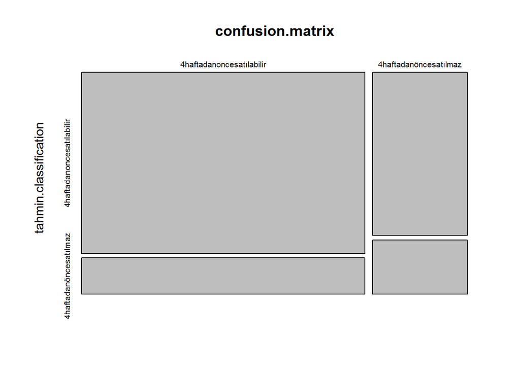

```r
plot(confusion.matrix)
```

### Doğruluk;

```r
accuracy<-sum(diag(confusion.matrix)/sum(confusion.matrix))
```

[output not shown]